# Section 1 - Model Complexity and Model Selection

**Student Name: Xinyu Zhang**

**Student ID: 35486244**

## Q1 KNN regressor

### Q2-I

#### Implement a KNN regressor using the scikit-learn conventions

```python
from scipy.spatial import KDTree
from scipy.stats import mode

# define the KnnRegression
class KnnRegression:

    def __init__(self, k):
        self.k = k

    def fit(self, x, y):
        self.y_train_ = y
        # use the KDTree to save x
        self.x_train_kdtree_ = KDTree(x)
        return self

    def predict(self, x):
        # use the KDTree to find the neighbours, neighbours is a row index of train set
        _, neighbours = self.x_train_kdtree_.query(x, k=self.k)
        neighbours = neighbours.reshape(len(x), self.k) # (n, k)
        #  get the mean as the predicting result
        neighbour_labels = self.y_train_[neighbours]
        m= np.mean(neighbour_labels, axis=1, keepdims=False)
        return m
```

### Q2-II

#### To test your implementation and load the dataset diabetes

```python
from sklearn.datasets import load_diabetes
# Load the load_diabetes dataset
diabetes = load_diabetes()

# diabetes.data, diabetes.target
```

```python
import numpy as np
# split the train set an test set(train_size=0.6)
def train_test_split(x, y, train_size=0.6, random_state=None):
    RNG = np.random.default_rng(random_state)
    N = len(x)
    N_train = round(N*train_size)
    idx_train = RNG.choice(N, N_train, replace=False)
    idx_test = np.setdiff1d(np.arange(N), idx_train)
    RNG.shuffle(idx_test)
    return x[idx_train], x[idx_test], y[idx_train], y[idx_test]

x_train, x_test, y_train, y_test = train_test_split(diabetes.data, diabetes.target, train_size=0.7, random_state=1)
```

```python
# train model and test
knn = KnnRegression(k=5)
knn.fit(x_train, y_train)
y_hat_test = knn.predict(x_test)
y_hat_test
```

```
array([158. , 196.8, 157.8, 138. , 130.2, 189.4,  76.8, 178.6,  83.6,
       175.4, 109. , 242.8, 218. , 154.4, 167. , 140.8, 143.2,  75.4,
       186.6, 265.4,  96. , 131.4, 116. ,  87. , 158.4, 275.4, 208.2,
       151.6, 125.2, 214.4, 119.8, 121.6, 142.2, 172.2, 200.2, 164.8,
       104.2, 191.2, 131.2, 110. , 127.2, 230.8, 106.4, 171. , 165. ,
       204.6, 195. , 259.8, 191.4, 102.2,  86.4, 286.8, 156.6, 163.8,
       229.8,  90.6,  94.8,  97.6, 213.4,  98. , 190. , 165. ,  80.6,
        78.4,  86.8, 239.8,  93.2,  91.8, 275.6,  88. , 236. , 247.8,
       123.8, 100.2, 103.6, 150.2, 161.2, 113.6, 136.8,  56.6, 175.8,
        96.6, 204.4, 283. ,  92.6, 226.4, 123.6,  97. ,  90.6, 188.8,
        80. , 194.6, 151. , 111.6, 142.4, 107. , 164. , 193.8,  54.4,
        97.2, 143. ,  74. , 117. , 212.6, 197.4, 117.8, 117.4, 206.6,
       100. , 149.4, 120.4,  93.6, 109. , 126.8, 157.2, 174.4, 226.4,
        59.2, 200.4, 266.2,  88.6, 121.2, 105.2, 112.4, 115.8, 200.4,
        91.2, 119.4,  86. ,  81.2, 190.6, 101. , 114.2])
```

### Q2

#### Q2-I

#### Implement a L-Fold Cross Validation (CV) scheme using the scikit-learn convention

```python
# define the L-Fold Cross Validation (CV) class
class LFold:

    def __init__(self, n_splits):
        # init the Fold number
        self.n_splits=n_splits

    def get_n_splits(self,x= None, y= None ,group= None):
        return self.n_splits

    def split(self, x, y= None, group= None):
        result = []
        if y is None:
            flods =np.array_split(x,self.n_splits)

            for i in range(self.n_splits):
                train = flods.copy()
                test = [flods[i]]
                del train[i]
                result.append((np.concatenate(train), np.concatenate(test)))

        else:
            # Combining x and y and get the folds
            x_plus_Y = np.hstack((x, y.reshape(y.shape[0], 1)))
            folds = np.array_split(x_plus_Y, self.n_splits)

            # save the x_train, x_test, y_train and y_test of Each fold, put in the list [()]
            for i in range(self.n_splits):
                train = folds.copy()
                test  = [folds[i]]
                del train[i]
                result.append((
                        np.concatenate(train)[:,:-1],  # X_train：All columns except the last
                        np.concatenate(test)[:,:-1],  # X_test
                        np.concatenate(train)[:,-1:],  # y_train：Take only the last column
                        np.concatenate(test)[:,-1:]   # y_test
                    ))
        return result
```

**LFold test**

```python
for idx_train, idx_test in LFold(5).split(list(range(20))):
    print(idx_train, idx_test)
```

```
[ 4  5  6  7  8  9 10 11 12 13 14 15 16 17 18 19] [0 1 2 3]
[ 0  1  2  3  8  9 10 11 12 13 14 15 16 17 18 19] [4 5 6 7]
[ 0  1  2  3  4  5  6  7 12 13 14 15 16 17 18 19] [ 8  9 10 11]
[ 0  1  2  3  4  5  6  7  8  9 10 11 16 17 18 19] [12 13 14 15]
[ 0  1  2  3  4  5  6  7  8  9 10 11 12 13 14 15] [16 17 18 19]
```

#### Q2-II

#### Use L-fold CV implementation to systematically test the effect of the KNN parameter K

```python
# Define the MSE function
def MSE(y,y_hat):
    return np.square(np.subtract(y,y_hat)).mean()

y_hat_train = knn.predict(x_train)
MSE(y_train,y_hat_train), MSE(y_test,y_hat_test)
```

```
(np.float64(2462.266148867314), np.float64(3708.017142857143))
```

```python
# fit and predict data, and finally return the MSE of training and testing
def runKnn(kValue, x_train, x_test, y_train, y_test):
    knn = KnnRegression(k=kValue)
    knn.fit(x_train, y_train)
    y_hat_train = knn.predict(x_train)
    y_hat_test = knn.predict(x_test)
    return MSE(y_train, y_hat_train), MSE(y_test, y_hat_test)
```

```python
# calculate the mse of test and train , and save the result
def df_stores(L, max_k):

    # Cross Validation
    results = []  # [KValue, LFoldID, MSE_train, MSE_test]
    kf = LFold(n_splits=L)

    # get the different k to run on the different fold
    for k in range(1, max_k+1):

        for fold_id, (x_train, x_test, y_train, y_test) in enumerate(kf.split(diabetes.data, diabetes.target)):

            mse_train, mse_test = runKnn(k, x_train, x_test, y_train, y_test)

            # save the result
            results.append([k, fold_id, mse_train, mse_test])

    # turn to the numply array
    results = np.array(results, dtype=float)
    return results
```

#### For each K compute the mean and standard deviation of the mean squared error (training and test)

```python
# calculate the mean mse and std mse group by k
def compute_mean_std(results):

    K_values = np.unique(results[:, 0]).astype(int)

    summary_list = []
    for k in K_values:
        rows = results[results[:, 0] == k]
        mse_train = rows[:, 2]
        mse_test = rows[:, 3]
        summary_list.append([
            k,
            np.mean(mse_train), np.std(mse_train),
            np.mean(mse_test), np.std(mse_test)
        ])

    return np.array(summary_list)
```

#### report the K for which you found the best test performance.

```python
# find the best k in the test
def find_best_k(summary_array):
    # the 4th column： MSE_test_mean
    test_means = summary_array[:, 3]
    best_idx = np.argmin(test_means)
    best_k = int(summary_array[best_idx, 0])
    return best_k
```

```python
# define the k and  l
max_k = 60
L = 40

# run the model in different k and l
results = df_stores(L, max_k)

# calculate the mean mse and std mse group by k
summary_array = compute_mean_std(results)

# print the top 15 results
print("K | MSE_train_mean | MSE_train_std | MSE_test_mean | MSE_test_std")
for row in summary_array[:15]:
    print(row)

# use find_best_k fun to get the best k
best_k = find_best_k(summary_array)
print("best_k:", best_k)
```

```
K | MSE_train_mean | MSE_train_std | MSE_test_mean | MSE_test_std
[1.00000000e+00 0.00000000e+00 0.00000000e+00 6.09106061e+03
 3.08849760e+03]
[2.00000000e+00 1.47417653e+03 3.05060950e+01 4.55752027e+03
 2.16763382e+03]
[3.00000000e+00 1.95907811e+03 4.11609902e+01 4.15417988e+03
 1.97491019e+03]
[   4.         2283.50622751   39.41479422 3754.24773911 1810.28439668]
[   5.         2355.32663912   39.52030551 3740.50613636 1719.84798395]
[   6.         2551.75457497   41.22569791 3623.42439499 1689.73669666]
[   7.         2616.23530451   41.26843175 3560.8455705  1567.22752708]
[   8.         2667.28977232   37.80774797 3480.90832446 1475.37070796]
[   9.         2710.6247931    39.4438108  3419.85749158 1397.08068736]
[  10.         2746.85948941   36.50402541 3415.08066856 1317.8240783 ]
[  11.         2785.43678021   36.96638716 3397.94107501 1313.21930645]
[  12.         2832.51623962   38.38659324 3375.26695602 1300.4044053 ]
[  13.         2841.80179004   35.66668113 3352.0279003  1303.13923648]
[  14.         2864.79152817   35.53500561 3342.30387871 1331.34088762]
[  15.         2866.89733055   37.52868286 3326.01419444 1327.25871825]
best_k: 18
```

#### Q2-III

#### plot the mean training and test errors against the choice of K with error bars

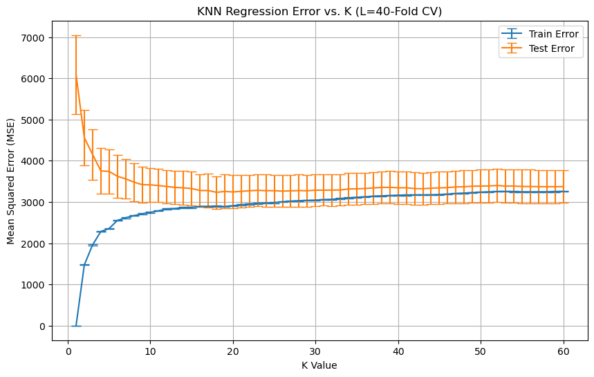

```python
from matplotlib import pyplot as plt

# summary_array: [KValue, MSE_train_mean, MSE_train_std, MSE_test_mean, MSE_test_std]
ks = summary_array[:, 0]   # K 值
train_means = summary_array[:, 1]
train_stds  = summary_array[:, 2]
test_means  = summary_array[:, 3]
test_stds   = summary_array[:, 4]

# Calculate the confidence interval
train_cis = 1.96 * train_stds / np.sqrt(L)
test_cis  = 1.96 * test_stds  / np.sqrt(L)

# plot the result with error bars
plt.figure(figsize=(10, 6))
plt.errorbar(ks, train_means, yerr=train_cis, label='Train Error', capsize=5)
plt.errorbar(ks, test_means,  yerr=test_cis,  label='Test Error',  capsize=5)
plt.xlabel('K Value')
plt.ylabel('Mean Squared Error (MSE)')
plt.title(f'KNN Regression Error vs. K (L={L}-Fold CV)')
plt.legend()
plt.grid(True)
plt.show()
```

#### Q2-III

#### The effect of the parameter K

As can be seen in the figure above, before k = 10, the difference between the test set error and the training set error is quite large (that is, the variance is large), and the training set bias is relatively small, so this stage is overfitting.

## Q3

#### Q3-I Implement a version of the KNN regressor that automatically chooses an appropriate value of K from a list of options

```python
from scipy.spatial import KDTree
import numpy as np

# define the KnnRegressionCV
class KnnRegressionCV:
    def __init__(self, m_k=60, L=5):
        self.m_k = m_k
        self.L = L

    def fit(self, X, y):
        self.y_train_ = y
        self.x_train_kdtree_ = KDTree(X)

        # use df_stores fun to get the train and test results
        results = df_stores(self.L, self.m_k)

        # calculate the mean mse and std mse group by k
        summary_array = compute_mean_std(results)

        # find the best k in the test by min MSE_test_mean
        self.k_best = find_best_k(summary_array)

        # calculate the mean k in the cross validation
        self.mean_k = find_mean_k(results)

        print("best_k (test):", self.k_best)
        print("Mean_k (internal CV):", self.mean_k)
        return self

    def predict(self, X, k=None):
        if k is None:
            k = self.k_best
        _, neighbours = self.x_train_kdtree_.query(X, k)
        neighbours = neighbours.reshape(len(X), k)
        neighbour_labels = self.y_train_[neighbours]
        return np.mean(neighbour_labels, axis=1, keepdims=False)

    def best_k(self):
        return self.k_best
```

#### Q3-II Test your KNN regressor with internal CV by using an outer single train/test-split

```python
# fit and predict data, and finally return the MSE of training and testing
def runKnncv(kValue, x_train, x_test, y_train, y_test):
    knn = KDTree(x_train)

    # predicting train set
    _, neighbours = knn.query(x_train, k=kValue)
    neighbours = neighbours.reshape(len(x_train), kValue)
    y_hat_train = np.mean(y_train[neighbours], axis=1)

    # predicting test set
    _, neighbours = knn.query(x_test, k=kValue)
    neighbours = neighbours.reshape(len(x_test), kValue)
    y_hat_test = np.mean(y_train[neighbours], axis=1)

    return MSE(y_train, y_hat_train), MSE(y_test, y_hat_test)
```

```python
# find the best k in the test
def find_best_k(summary_array):

    # the 4th column：MSE_test_mean
    test_means = summary_array[:, 3]
    best_idx = np.argmin(test_means)
    best_k = int(summary_array[best_idx, 0])
    return best_k
```

```python
# calculate the mean k in the cross validation
def find_mean_k(results):
    # get the all fold ids
    folds = np.unique(results[:, 1]).astype(int)
    best_ks = []

    for fold_id in folds:
        # put the same fold id rows together
        fold_rows = results[results[:, 1] == fold_id]
        mse_tests = fold_rows[:, 3]
        best_idx = np.argmin(mse_tests)
        best_k = int(fold_rows[best_idx, 0])
        best_ks.append(best_k)
    # return a mean of the best k in cv
    return int(np.ceil(np.mean(best_ks)))
```

```python
# Create and train KnnRegressionCV
knncv = KnnRegressionCV(m_k=40, L=5)
knncv.fit(x_train, y_train)
```

```
best_k (test): 19
Mean_k (internal CV): 18
```

```
<__main__.KnnRegressionCV at 0x1c230fd7910>
```

#### Q3-II

#### Report on the (mean) k value that is chosen by the KNN regressor with internal cross validation and whether it corresponds to the best k-value with respect to the outer test sets.

#### Comment on which factors determine the success or failure of roughly selecting the best model.

#### Results Comparison

**Mean k (internal CV): 18** This is obtained by selecting the optimal k value for each fold and then averaging the results. It reflects the overall model complexity favored by cross-validation.

#### Factors Affecting Cross-Validation's Success in Approximating the Optimal Model

**Sample Size**

The larger the sample size, the more stable the cross-validation results and the more they represent the true data distribution. With a small sample size, the cross-validation variance will be greater.

**Cross-Validation Folds**

Too few folds: This results in an overly large validation set and a too small training set, leading to large estimation bias.

Too many folds: Although more training data is used, the validation set is too small, making the results susceptible to noise.

**Data Distribution and Noise**

If the data contains a lot of noise, a small k is more susceptible to noise, while a large k can smooth out the noise. Different levels of data noise can affect the selection of the optimal k.